# STATS 769 Lab 05

## The Data

The data are trips on electric scooters and bikes in Austin, Texas, which are made available via the official City of Austin data portal.

## Data Import

The request includes number of arguments: an “app token” for identification; a specification of the year we want trips from and the type of trips we want; a specification of the columns we want returned; and the number of trips we want returned.

It is also ok to use the ‘RSocrata’ package, but make sure that you understand how this ‘httr’ approach works (in case there are questions on it in the exam).

```r
library(httr)
harvest <- function(year, type, limit) {
    response <- GET("https://data.austintexas.gov/resource/7d8e-dm7r.json",
                    query=list("year"=year,
                               "vehicle_type"=type,
                               "$select"="trip_duration,trip_distance",
                               "$offset"=0,
                               "$limit"=limit,
                               "$order"=":id",
                               "$$app_token"="cnBKgWZRxb2MySoKE0iwuDYtt"))
    content(response)
}
tripsJSON <- harvest(2018, "scooter", 10000)
```

The result of our request is a list of lists of character values. We turn each sublist into a character vector with `unlist()`, then `rbind()` the vectors together to form a matrix.

```r
tripMatrix <- do.call(rbind,
                      lapply(tripsJSON, unlist))
```

We generate a data frame of the durations and distances and convert both columns to numeric values.

```r
scooterTrips2018 <- data.frame(trip_duration=as.numeric(tripMatrix[,1]),
                               trip_distance=as.numeric(tripMatrix[,2]))
```

## R processing

```r
trips <- subset(scooterTrips2018, trip_duration > 0 & trip_distance > 0)
longTrip <- trips$trip_distance > 1000
tripDuration <- log(trips$trip_duration)
```

This leaves us with 8702 trips to analyse.

## Fitting models

We split the data into training and test sets.

```r
testIndex <- sample(seq_along(tripDuration), .2*length(tripDuration))
trainx <- tripDuration[-testIndex]
trainy <- longTrip[-testIndex]
testx <- tripDuration[testIndex]
testy <- longTrip[testIndex]
```

We fit a logistic regression to the training set and then evaluate its performance on the test set.

```r
glmFit <- glm(y ~ x, data.frame(x=trainx, y=trainy), family="binomial")
glmProb <- predict(glmFit, data.frame(x=testx), type="response")
glmPred <- glmProb > .5
glmDiag <- caret::confusionMatrix(factor(glmPred), factor(testy))
glmDiag$table
```

```
          Reference
Prediction FALSE TRUE
     FALSE   727  196
     TRUE    138  679
```

```r
glmDiag$overall["Accuracy"]
```

```
Accuracy
0.808046
```

Next, we fit a $k$-nearest neighbours model and evaluate its accuracy. This shows a slightly better accuracy than the logistic regression.

```r
knnPred <- class::knn(matrix(trainx, ncol=1),
                      matrix(testx, ncol=1),
                      trainy,
                      k=51, prob=TRUE)
knnProb <- ifelse(as.logical(knnPred),
                  attr(knnPred, "prob"),
                  1 - attr(knnPred, "prob"))
knnDiag <- caret::confusionMatrix(knnPred, factor(testy))
knnDiag$table
```

```
          Reference
Prediction FALSE TRUE
     FALSE   687  143
     TRUE    178  732
```

```r
knnDiag$overall["Accuracy"]
```

```
 Accuracy
0.8155172
```

## Comparing the models

The following plot shows the rough pattern of shifting proportions of long trips as a function of trip duration (black dots), with the smooth, monotonic logistic regression predictions as a red line, and the sharp, multiple transitions of the $k$-nearest neighbours model as a green line.

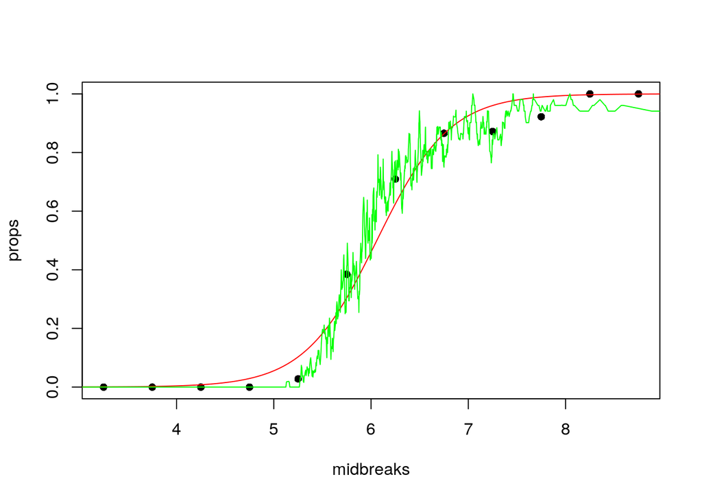

```r
breaks <- seq(3, 9, .5)
midbreaks <- breaks[-1] - diff(breaks)/2
props <- tapply(testy, cut(testx, breaks), mean)
plot(midbreaks, props, pch=16)
o <- order(testx)
lines(testx[o], glmProb[o], col="red")
lines(testx[o], knnProb[o], col="green")
```

## Conclusion

We obtained the data from the original source via requests to a web API, extracting just trip distances and durations for scooter trips from 2018.

We removed non-positive values from both variables, logged the durations, and created a new “long trip” variable (trips longer than 1km).

A logistic regression model predicts the proportion of long trips from trip duration quite well.

A $k$-nearest neighbour model predicts slightly better, but the jaggedness in the predictions is probably less realistic than the smooth trend of the logistic model for these data. There does appear to be a quite well-behaved smooth transition in the proportion of long trips as the trip duration increases and that is nicely captured by the relatively simple logistic regression model.